# TB: exploring the case of TB elimination with a simple compartmental model

Ending Tuberculosis (TB) and elimination are terms now more present than ever in the Global Health agenda. Is it achievable? how and when could this happen?. All this is yet uncertain, and an ongoing discussion in the field. In this practical, we intend to illustrate important concepts of TB epidemiology by setting up a simple compartmental model and trying to assess what would be required to End TB goals as set by WHO and/or elimination thresholds.

## Core concepts

The following concepts will be developed further during the practical:

- Compartmental Models
- Flow diagrams
- Long-term infection dynamics
- Natural History of TB
- TB control strategies

## Required packages

```r
#install.packages("deSolve", dep=TRUE)
#install.packages("gridExtra", dep = TRUE)
#install.packages("ggplot2", dep = TRUE)
```

## Part I: Set up a basic TB model

### Natural History of TB

Tuberculosis is an infectious disease caused by *Mycobacterium* *tuberculosis*. Pulmonary tuberculosis (PTB) is the most prevalent manifestation of the disease and also the form more likely to be infectious. TB is transmitted from person to person via micro droplets sprayed by an infectious individual when they cough or sneeze. Studies of household contacts and phylogenetic analysis have estimated the transmission potential of the average infectious TB case to be between 4 and 18 secondary cases per year (1).

An important feature in the timeline of TB infection is the latent period. The vast majority of newly infected individuals progress into a latent stage where *M. tuberculosis* remains dormant in a non-replicative stage, and as such, non-infectious. Breaking out from the latent stage into active pulmonary disease is a process mediated by several risk factors, and one that in most cases never realizes. At the population level it is accepted as a broad estimation that 10% of latent infections will break into active disease during a life-span (2). On the other hand, we also know that ~10% of new TB transmission events will fast-track into active TB disease (3). Active TB cases, as we discussed above, are symptomatic and infectious. Intermediate stages of subclinical active TB are currently recognized, but for simplicity we will accept here that symptomatic disease equals infectiousness.

The average duration of the infectious period is ~3 years. Cohort studies have established that after this period roughly 50% of active TB cases die from the disease, while the other 50% recover spontaneously (4). TB does not confer complete immunity after recovery, however partial immunity has been observed in previously infected and might protect from reinfection (HR ~0.5) (5). Finally, individuals who had recovered from active TB are not only susceptible for re-infection, but they can relapse into active disease, usually at a yearly rate of around 0.5% (6).

**1) Following the statement above, can you complete the table of parameters? Draw a flow chart if necessary.**  
*(Note: All parameters with prefix T. are in a scale of time (years). Use this parameters to calculate the missing rates as necessary).*

First, let’s load some libraries we need.

```r
#Load packages
library(deSolve)
```

```r
library(gridExtra)
library(ggplot2)
library(reshape)
```

Now, complete the parameter list below:

```r
# Model Parameters
T.lfx    <- 72              # Life expectancy
T.dur    <-                 # Duration of infectious period
beta     <-                 # Transmission rate per capita
break_in <-                 # Transition rate from latent into active disease
selfcure <-                 # Rate of spontaneous cure
mu       <- 1/T.lfx         # Background mortality rate
mu_tb    <-                 # TB mortality rate
fast     <-                 # Fraction fast progressing to active TB
imm      <-                 # Infectiousness decline (partial immunity)
relapse  <-                 # Relapse rate
```

Now we have a full list of parameters and a general idea of the flows between compartments. The code you will find below describes the set of ordinary differential equations that describe our system. Each equation (named with prefix *d*) represent a compartment in our model with respective flows in and out, at each time step.

During the lecture the concept of recent *vs.* remote incidence was introduced. Since we want to set up a model that allows us to track our epidemic changes over time and under different interventions, we need to code model outputs for the recent and remote incidence components.

**2) Look at the code below. Using the rates and stages in the first equations, code the model outputs for remote and recent TB incidence:**

*Copy and Paste the code below*

```r
TB.Basic <- function (t, state, parameters) {
  with(as.list(c(state,parameters)),
       {
         N      <- U + L + I + R            # Total population
         births <- I * mu_tb + N * mu       # Births (for stable population)
         lambda <-   beta * I/N             # Force of Infection

         # Uninfected
         dU <- births - U * (lambda+mu)

         # Latent
         dL <-  U * lambda * (1-fast) + R * (lambda * (1-fast) * imm) - L * (mu + break_in)

         # Active TB
         dI <-  U * lambda * fast + R * (lambda * fast * imm) +  L * break_in + R * relapse -
           I * (mu + mu_tb + selfcure)

         # Recovered
         dR <-  I * selfcure - R * (lambda * imm + relapse + mu)

         # Model outcomes
         dIncidence <- U * (lambda * fast) + R * (lambda * fast * imm) + L * break_in + R * relapse

         #::::::::: TRY  TO COMPLETE THIS EQUATIONS

         dIrecent   <-

         dIremote   <-

         #::::::::::::::::::::::::::::::::::::::::::::

         #wrap-up
         dx <- c(dU, dL, dI, dR, dIncidence, dIrecent , dIremote)
         list(dx)
       }
  )
}
```

**3) Looking at the code above, can you write down (*on paper*) the differential equations for this model?**

Now that we have a model coded and parameterised, let’s run our code and check how TB incidence looks like.

But before, we have to create a handy function that will help us run our models under different conditions along this practical and will return some plots and data. We will be calling this function repeatedly during the practical.

*(Note: for this section, copy and paste the code shown and try to understand what is going on in each section. Hopefully, commenting in the code is transparent enough!. Organise your own script in sections to keep track of our exercise)*

*Copy and Paste the code below*

```r
get_intervention<- function (sfin, params_new, params_old,times_new,
                             t.interv, fx_scale,fx_basic, int_name, data_stub) {

  # Starting conditions
  xstart <- c(U = sfin$U,
              L = sfin$L,
              I = sfin$I,
              R = sfin$R,
              Incidence= sfin$Incidence,
              Irecent=   sfin$Irecent,
              Iremote=   sfin$Iremote)

  #Select type of function
  if (is.na(t.interv))
  {
    fx<-fx_basic
  }  else {
    fx<-fx_scale
  }

  #Run the model
  out <- as.data.frame(ode(y = xstart, times = times_new,
                           func = fx, parms = params_new))  #
  # Model output
  N            <- out$U+out$L+out$I+out$R
  rate.inc    <- 1e5*(diff(out$Incidence)/N[1:length(N)-1])
  fr.remo     <- diff(out$Iremote)/diff(out$Incidence)
  time         <- out$time[1:length(out$time)-1]
  dat         <- data.frame(Years=time+(2019-400), Incidence=rate.inc)
  dat$Sim     <- int_name

  # If it is a first run, nothing to append
  if (is.na(data_stub))
  {
    data<-dat
  }
  else # Append previous runs
  {
    data  <-rbind(data_stub, dat)
  }

  remote<-fr.remo  # rename a variable with the fraction of remote incidence
  titl  <-int_name

  # Create our plot
  p<- ggplot(data=data, mapping = aes(x=Years, y=Incidence, col=Sim))
  p1<-p +
    geom_line(size=1.2) +
    ggtitle ('TB Incidence') +
    theme_bw() + ylab('Rate per 100,000 pop')+
    ylim(0,max(data$Incidence))

  # Pie chart of remote vs recent incidence
  df <- data.frame(
    Source = c("Recent", "Remote"),
    value  = c(1-tail(remote,1),tail(remote,1))
  )

  mycols <- c("#0073C2FF", "#EFC000FF")
  pie<- ggplot(df, aes(x="", y=value, fill=Source))+
    geom_bar(width = 1, stat = "identity") +
    coord_polar("y", start=0)+
    scale_fill_manual(values = mycols) +
    theme_void()+
    ggtitle (titl)

  output<-list("out"=out, "lines"=p1, "pie"=pie, "data"=data)

  # Spit-out results
  return(output)

}
```

Set some simulation parameters

*Copy and Paste the code below*

```r
t.intervention <- 400      # years of simulation
t.scale        <- 3        # Scaling up time of interventions
times  = seq(0, t.intervention, by=1)          # time scale
```

Create our parameter list and initial conditions

*Copy and Paste the code below*

```r
#Prepare tu run
params <- c(break_in=break_in, selfcure=selfcure, mu=mu, mu_tb=mu_tb
            ,beta=beta, fast=fast, imm=imm, relapse=relapse)   # running parameters

# Initial Conditions
N <- 1                  # Total population equal to unity
I0 <-1e-6               # TB seed at time 0

xstart <- data.frame(U = N-I0,
            L = 0,
            I = I0,
            R = 0,
            Incidence=0,
            Irecent=0 ,
            Iremote=0)
```

Now, let’s solve our system

*Copy and Paste the code below*

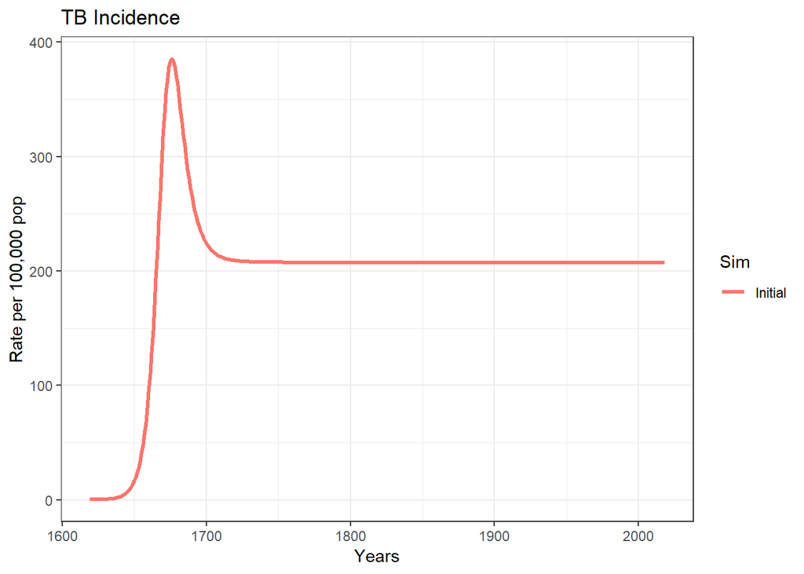

```r
#run the model
out  <-get_intervention(xstart, params, NA,times,
                        NA, NA,TB.Basic, "Initial", NA)
#plot
out$lines
```

We have produced and incidence trajectory for a system that seems to be in endemic equilibrium. What does this mean?

**4) Can you take a moment and try to explain in a few words what it means for an epidemic to achieve an endemic equilibrium?**

**5) Making use of concepts from your previous lectures, can you think of a simple mathematical expression for the endemic equilibrium in terms of the basic reproduction number ($R_0$) ?**

We could attempt to estimate $R_0$ for the given model with a simple rearrange of terms in our previous equation. However, there are factors specific to the natural history of TB that can corrupt our common interpretation of reproduction numbers as we usually do with acute infections.

**6) Can you think of at least two factors specific to the natural history of TB that can complicate our interpretation of $R_0$ and $R_t$ ?**

## Part II: explore the case for TB elimination

Now we have some understanding of TB dynamics, and we want to explore the case of TB elimination using our model. To make the case more interesting we can try and get our TB incidence trajectory match the current estimation for a high TB burden country.

**1) Explore WHO’s TB country profiles for the 30 countries with the highest TB burden ( [here](https://www.who.int/tb/publications/global_report/gtbr2017_annex2.pdf?ua=1) )**

**2) Select a country with an incidence trend that resembles the unchanged trend in our model. Then, take note of the TB incidence rate per 100K estimation (including HIV/TB).**

**3) In the code below replace the missing variables for country incidence, country name and beta parameter. Vary the value of beta until your incidence trajectory matches the data point in the plot. (Run the code as many times as necessary)**

*Copy and Paste the code below*

```r
#:::::: FILL THE MISSING VALUES HERE

Inc.country   <-  # TB incidence per 100K (including TB/HIV)
country.name  <-  # e.g., "Sierra Leone"
params["beta"]<-  # Transmission rate per capita per year
#::::::


#run the model
out0  <-get_intervention(xstart, params, NA,times,
                        NA, NA,TB.Basic, "Initial", NA)

#plot
dot<-data.frame(Data="Bangladesh",Years=2017, incidence=Inc.country)

p1<-out$lines +
  geom_point(dot, mapping=aes(x=Years, y=incidence, col=Data), size=6, shape=18)

#Arrange plots in a nice grid
grid.arrange(p1,out$pie)
```

Explore your model fit, visually

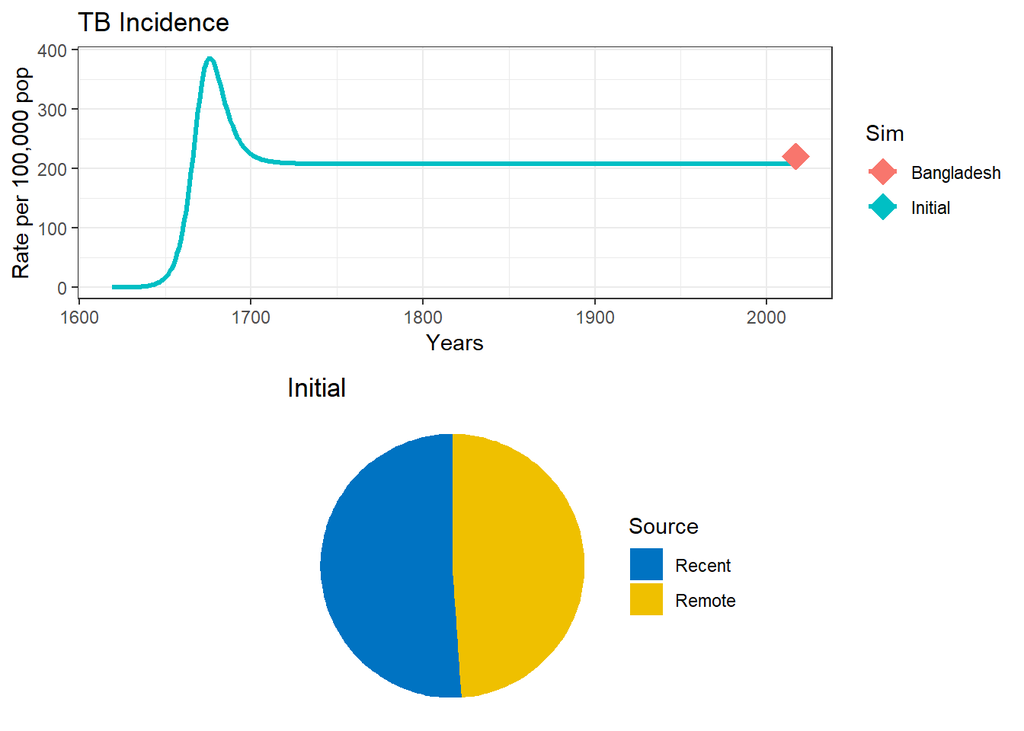

**4) Can you think of other ways in which the model parameters govern the overall size of the epidemic and in this case the incidence rate at equilibrium?**

To move-on with rolling out the interventions in our model we need a few more steps to get our functions ready, so we can call them when needed.

First, we need to create a wrapper function that allows us to scale-up our interventions smoothly over a period of time. Copy and execute the code below:

*Copy and Paste the code below*

```r
# Intervention scaling function
scale_up<- function (t, state, parameters,t.interv,parameters_old,fx) {

  scale <- min((t-t.interv[1])/(t.interv[2]-t.interv[1]),1);
  if (scale<0)
    {
    scale=0
    }

  pars_scaled <- parameters;

  pars_scaled <- parameters_old + scale*(parameters-parameters_old)

  return(fx(t, state,pars_scaled))
}
```

Let’s create some function handles to pass as arguments.

*Copy and Paste the code below*

```r
# Function handles

fx_basic<-TB.Basic
fx_scale<-function(t, state, parameters) scale_up(t, state, parameters,t.interv,params,fx_basic)
```

Now, lets create a baseline incidence to use as counterfactual in our exploration of TB elimination.

*Copy and Paste the code below*

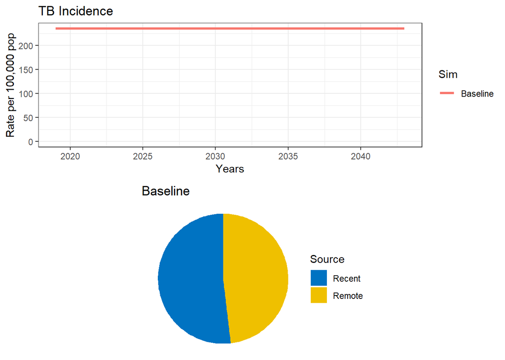

```r
## Simulation 0
# Project a baseline
int_name   <- "Baseline"

#Initial conditions (starting in 2019)
sfin       <- tail(out0$out,1)
params_base<- params
times_new  <- seq(t.intervention, t.intervention+25 , by=1)
t.interv   <- c(times_new[2], times_new[2]+t.scale)

#Run model
data0<-get_intervention(sfin, params_base, params_base,times_new,
                             NA, fx_scale,fx_basic, "Baseline", NA)
#Plot
grid.arrange(data0$lines ,data0$pie )
```

## *TB treatment*

We will start our exploration of interventions by simulating the roll-out of a successful TB treatment campaign. For simplicity, we want to do so without altering our current model structure. The simplest way is to alter the rate of spontaneous cure.

In the pathway to successful (curative) TB treatment, there are a number of events an individual should go through.

1. Careseeking rate (cs): We can define careseking as the time it takes for a symptomatic individual to seek for medical care
2. Probability of diagnosis (pDx): the probability that once an individual has sought care, a diagnostic test will be performed
3. Probability of treatment (pTx): probability that once an individual has been diagnosed, treatment will be prescribed
4. Treatment duration (T.rtx): Total duration of the treatment course (standard TB treatment is 6 months)

For the sake of simplicity we will not include other factors that might also play a role in treatment success.

**5) Can you list at least two other factors related to TB treatment success?**

**6) In the code below, assign values to the variables that reflect the components of TB treatment. Consider an average careseeking delay of 1 year, a probability of diagnosis of 95%, and treatment initiation of 95%.**

**7) Write the code for the term Tx. (Note that Tx is a rate that will add to the existing self cure rate in your model). Run the code to see your results.**

```r
## Simulation 1
# An Intervention simulating introduction of treatment
int_name   <- "Treatment"

#Update parameter results data frame to append new results
params_1 <-params_base
data_stub<-data0$data

#:::: COMPLETE THE MISSING VALUES AND WRITE A TERM FOR RATE Tx

# Change parameters for intervention
T.cs <-       # Time delay (yrs) between developing symptoms and seeking for care
pDx  <-       # Probability of being diagnosed once sought care
pTx  <-       # probability of recieving correct Tx if diagnosed
T.rTx<-   0.5 # 6 months treatment duration
Tx <-

#::::

params_1["selfcure"]<-selfcure + Tx

data1<-get_intervention(sfin, params_1, params_base,times_new,
                       t.interv, fx_scale,fx_basic, int_name, data_stub)

p1<-data1$lines +
  # EndTb
  geom_hline(yintercept=Inc.country*0.1, linetype="dashed", color = "black", size=1)+
  # Elimination
  geom_hline(yintercept=0.1/1e5, linetype="dashed", color = "red", size=1)


grid.arrange(p1 ,data1$pie )
```

You should be looking at a plot similar to the one below.

**8) What can you say about the proportion *Recent vs. Remote* ?**

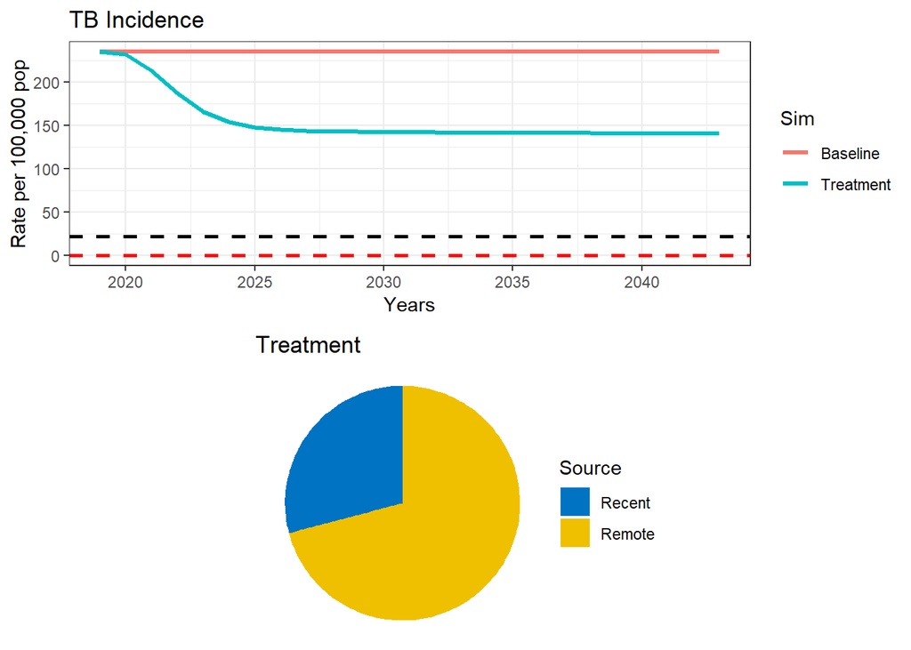

## *Increase the demand for TB services*

Now, let’s combine the treatment campaign with an intervention that make TB services widely available in the community. This intervention should increase the current yield of TB prevalent cases screened by 75%.

**9) What parameters in our previous simulation would you alter to simulate such intervention? Modify the code below and run.**

*(Note: remember that we want to combine interventions, i.e., the previous intervention should be introduced here too)*

```r
## Simulation 2
# An Intervention simulating demand generation
int_name   <- "Demand generation"

#Update parameter results data frame to append new results
params_2 <-params_1
data_stub<-data1$data

#::::::: COMPLETE THE MISSING VALUES AND WRITE A NEW TERM FOR Tx

# Change parameters for intervention
T.cs <-      # Time delay (yrs) between developing symptoms and seeking for care
pDx  <-      # Probability of being diagnosed once sought care
pTx  <-      # probability of receiving correct Tx if diagnosed
T.rTx<-      # 6 months treatment duration

Tx <-

#:::::::::::


params_2["selfcure"]<-selfcure + Tx

data2<-get_intervention(sfin, params_2, params_base,times_new,
                       t.interv, fx_scale,fx_basic, int_name, data_stub)

p1<-data2$lines +
  # EndTb
  geom_hline(yintercept=Inc.country*0.1, linetype="dashed", color = "black", size=1)+
  # Elimination
  geom_hline(yintercept=0.1/1e5, linetype="dashed", color = "red", size=1)


grid.arrange(p1 ,data2$pie )
```

Our plot should look like this..

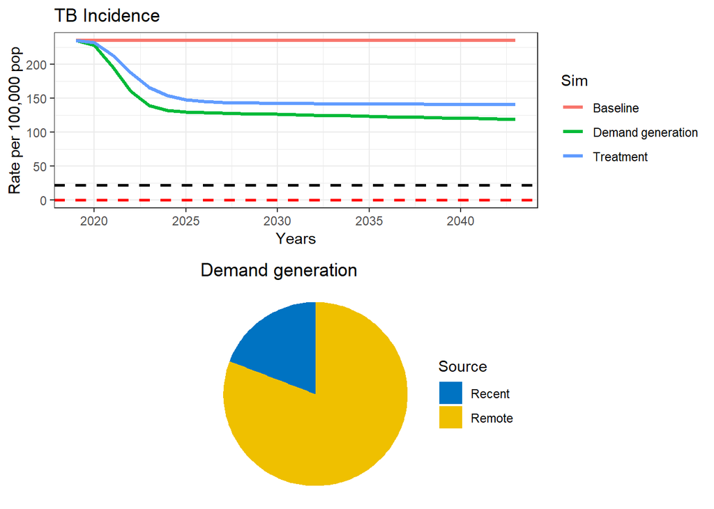

We can see from our remote/recent pie chart that even after a strong combined campaign to reduce TB burden, some transmission remains.

## *TB transmission control*

Let’s imagine a hypothetical scenario where transmission is completely shut down. This is practically unfeasible, but for the sake of testing our elimination case let’s imagine we can stop transmission with a fully curative intervention in every single prevalent case.

**10) Run the code below.**

*Copy and Paste the code below*

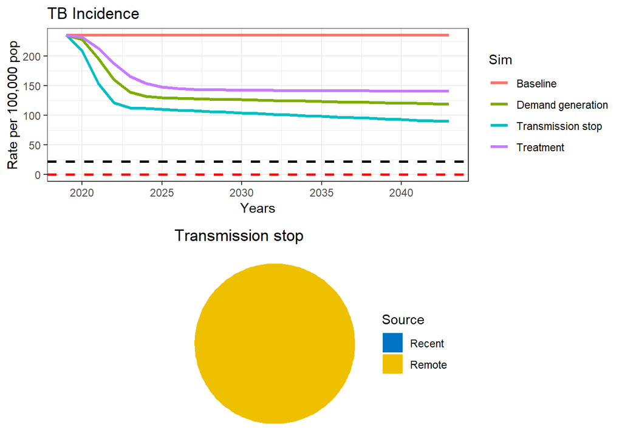

```r
## Simulation 3
int_name<-"Transmission stop"

#Update parameter results data frame to append new results
params_3 <-params_2
data_stub<-data2$data

# An Intervention simulating transmission reduction

params_3["beta"]<-0


data3<-get_intervention(sfin, params_3, params_base,times_new,
                       t.interv, fx_scale,fx_basic, int_name, data_stub)

p1<-data3$lines +
  # EndTb
  geom_hline(yintercept=Inc.country*0.1, linetype="dashed", color = "black", size=1)+
  # Elimination
  geom_hline(yintercept=0.1/1e5, linetype="dashed", color = "red", size=1)


grid.arrange(p1 ,data3$pie )
```

A fully curative intervention appears insufficient to drive the TB epidemic to elimination.

**11) If transmission has stopped (as seen in the pie chart), where is the remaining incidence coming from?**

**12) Where should we intervene to finally drive the TB epidemic down?**

## *LTBI treatment*

**13) Run the code below**

*(Note that the black dashed line below represent the End TB goal and the read dashed line is the elimination threshold)*

*Copy and Paste the code below*

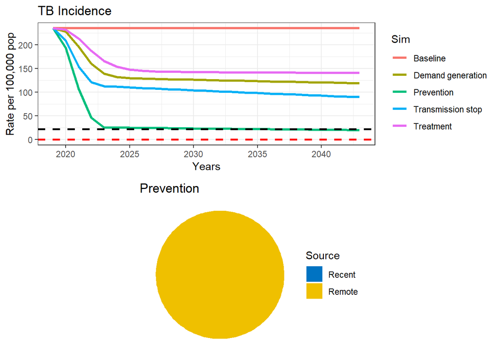

```r
## Simulation 4
# An Intervention simulating LTBI treatment
int_name<- "Prevention"

#Update parameter results data frame to append new results
params_4 <-params_3
data_stub<-data3$data

params_4["break_in"]<-0.01*(1/T.lfx)

data4<-get_intervention(sfin, params_4, params_base,times_new,
                       t.interv, fx_scale,fx_basic, int_name, data_stub)

p1<-data4$lines +
  # EndTb
  geom_hline(yintercept=Inc.country*0.1, linetype="dashed", color = "black", size=1)+
  # Elimination
  geom_hline(yintercept=0.1/1e5, linetype="dashed", color = "red", size=1)


grid.arrange(p1 ,data4$pie )
```

This final intervention scenario reach the goal for End TB just before 2035 but is still far from elimination.

We have coded and run a simple TB model for exploring the case of TB elimination and WHO’s End TB goal. Even though we did not formally assessed this subject, our simple exercise suggests that a combination of curative and preventive measures will be required to achieve at least End TB goals in a high burden setting.

Finally, take a few minutes to think how the following added complexities to the model could affect our estimations:

1. Age structure
2. Risk groups (e.g. HIV, Slum dwellers, diabetes, malnourished)
3. MDR-TB

## References

1. [World Health Organization . Global Tuberculosis Control: WHO Report 2011. Geneva: WHO; 2011.](https://apps.who.int/iris/handle/10665/44728)
2. [Horsburgh CR, O’Donnell M, Chamblee S, Moreland JL, Johnson J, Marsh BJ, et al. Revisiting rates of reactivation tuberculosis: a population-based approach. Am J Respir Crit Care Med. 2010;182(3):420-5.](https://www.ncbi.nlm.nih.gov/pmc/articles/PMC2921602/)
3. [Vynnycky E, Fine PE. The natural history of tuberculosis: the implications of age-dependent risks of disease and the role of reinfection. Epidemiol Infect. 1997;119(2):183-201.](https://www.ncbi.nlm.nih.gov/pubmed/9363017)
4. [Tiemersma EW, van der Werf MJ, Borgdorff MW, Williams BG, Nagelkerke NJ. Natural history of tuberculosis: duration and fatality of untreated pulmonary tuberculosis in HIV negative patients: a systematic review. PLoS One. 2011;6(4):e17601.](https://www.ncbi.nlm.nih.gov/pubmed/21483732)
5. [Andrews, J.R., et al., Risk of progression to active tuberculosis following reinfection with Mycobacterium tuberculosis. Clin Infect Dis, 2012. 54(6): p. 784-91.](https://www.ncbi.nlm.nih.gov/pubmed/22267721)
6. [Thomas A, Gopi PG, Santha T, Chandrasekaran V, Subramani R, Selvakumar N, et al. Predictors of relapse among pulmonary tuberculosis patients treated in a DOTS programme in South India. Int J Tuberc Lung Dis. 2005;9(5):556-61.](https://www.ncbi.nlm.nih.gov/pubmed/15875929)

# About this document

## Contributors

- [Juan F. Vesga](https://www.imperial.ac.uk/people/j.vesga10)

The source file is hosted on [github](https://github.com/juanvesga/TBpractical/blob/master/tb_practical.Rmd).